# a3_task3_morganne_sigismonti.Rmd

Morganne Sigismonti

11/1/2020

Read in the urchins data and clean up the column names.

```r
urchins_data <- read_csv(here("data", "urchins.csv")) %>%
  clean_names()
```

# Section 1

## Size comparisons of the purple and red urchins

### i) Exploratory Data Visualization

- Comparing the distribution of sizes between purple and red sea urchins using a Faceted Histogram.

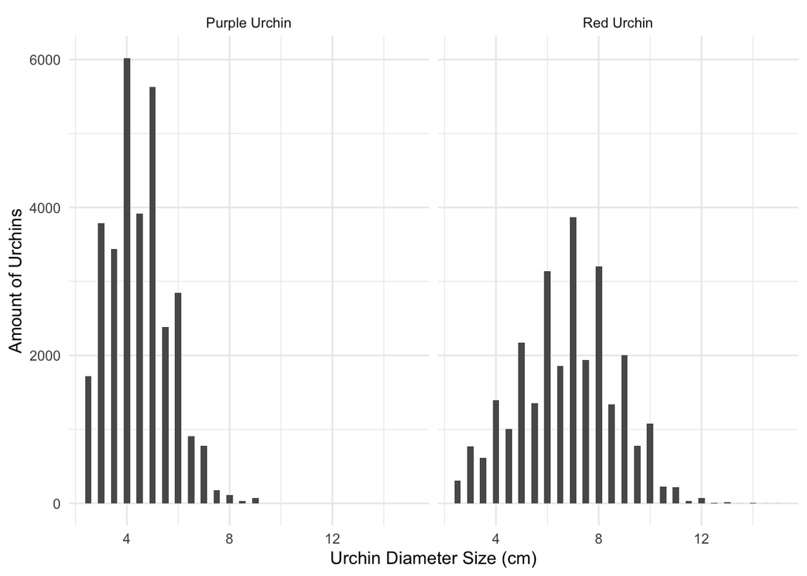

```r
ggplot(data = urchins_data, aes(x = size)) +
  geom_histogram(binwidth = .25) +
  facet_wrap(~ common_name) +
  labs(x = "Urchin Diameter Size (cm)", y = "Amount of Urchins") +
  theme_minimal()
```

- Comparing the distribution of sizes between purple and red sea urchins using a Boxplot

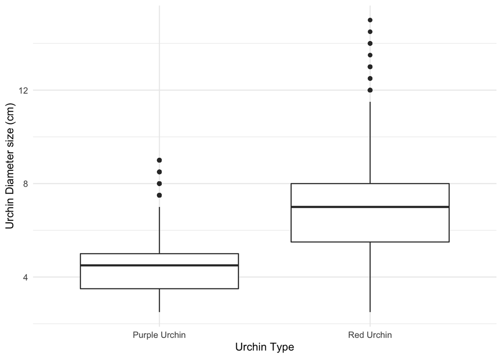

```r
ggplot(data = urchins_data, aes(x = common_name, y = size)) +
  geom_boxplot() +
  labs(x = "Urchin Type", y = "Urchin Diameter size (cm)") +
  theme_minimal()
```

### ii) Descriptive Statistics Table

- A summary table that contains the mean, median, standard deviation of the purple and red urchin diameter and sample size of the purple and red urchins.

```r
urchin_stats <- urchins_data %>%
  group_by(common_name) %>%
  summarize(mean = mean(size),
            median = median(size),
            sd = sd(size),
            sample_size = n())

 kbl(urchin_stats)%>%
   kable_classic()
```

| common_name | mean | median | sd | sample_size |
| --- | --- | --- | --- | --- |
| Purple Urchin | 4.469797 | 4.5 | 1.175264 | 31805 |
| Red Urchin | 6.776489 | 7.0 | 1.891343 | 27408 |

### iii) Overall Takeaways

- Actual difference between the mean urchin diameter between the Red and Purple urchin species

```r
6.776489 - 4.469797
```

```
## [1] 2.306692
```

- Percent difference between the mean urchin diameter between the Red and Purple urchin species

```r
(6.776489 - 4.469797) / ((4.469797+ 6.776489) / 2) * 100
```

```
## [1] 41.0214
```

# Section 2

## Exploring purple urchin count by site and year

### i) Created purple_urchins subset.

- Filter to only include observations for purple urchins
- Convert the date to class “Date”
- Create a new column that only contains the year
- Create a new column called site_full that contains the full name (not abbreviation) for each of the five sites: NAPL = Naples Reef, AQUE = Arroyo Quemado Reef, CARP = Carpinteria Reef, MOHK = Mohawk Reef, IVEE = Isla Vista Reef.

### ii) Made a summary table containing the total number of purple urchins observed by site and year.

```r
purple_urchins_totals <- purple_urchins %>%
  select("site_full", "year") %>%
  group_by(site_full, year) %>%
  count(site_full)
```

### iii) Made an exploratory graph of counts of purple urchins recorded at each site over time for the years included in the study.

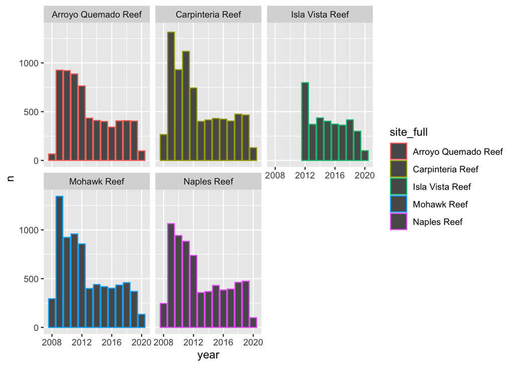

```r
ggplot(data = purple_urchins_totals, aes(x = year, y = n))+
  geom_col(aes(color = site_full)) +
  facet_wrap(~site_full)
```

THE END! WOO HOO!